# PCA Report

Lucia Jani

2025-05-17

```r
library(ggplot2)
library(factoextra)
```

## questions

1. Transform the Gaussian outcome ‘quality index’ into a binary outcome (i.e. good quality=1/poor quality=0), with a cut-off at 60, and analyze the data taking into account the available covariates.

We have conducted an additional small experiment on the size of the pears, and the soil conditions related to the yield of pears per tree. We would like you to answer the following questions:

2. Analyze the outcome ‘size’ of the pears over time, taking into account the covariates.
3. Explore/Visualize the soil condition features with a multivariate method.
4. Confirm (part of) the conclusions of your data analysis on effect of climate on the pear production using a multivariate method.

```r
soil_data <- read.csv("C:/Users/simba/OneDrive/Desktop/semester 2/Project multivariate/G6.soil.data (1).csv")
head(soil_data)
```

|  | species | ecotr_id | climate | Bulk.Density | Infiltration | Soil.Porosity | Soil.Depth | Water.Holding.Capacity | Soil.Nitrate | Soil.pH | Phosphorus | Potassium | Earthworms | Microbial.Biomass.C | Microbial.Biomass.N | Particulate.Organic.Matter | Mineralizable.N | Soil.Enzymes | Soil.Respiration | Total.Organic.Carbon | pears |
| --- | --- | --- | --- | --- | --- | --- | --- | --- | --- | --- | --- | --- | --- | --- | --- | --- | --- | --- | --- | --- | --- |
| 1 | Conference | 1 | Scenario 1 | 1.33 | 6.87 | 37.39 | 90.52 | 31.89 | 20.37 | 6.33 | 34.56 | 217.27 | 19.81 | 92.78 | 5.84 | 2.80 | 12.50 | 1.75 | 40.43 | 0.99 | 34 |
| 2 | Conference | 1 | Scenario 1 | 1.30 | 1.87 | 24.99 | 85.06 | 20.22 | 15.73 | 7.10 | 8.26 | 121.03 | 19.73 | 178.32 | 14.60 | 2.76 | 10.02 | 0.98 | 54.11 | 1.72 | 26 |
| 3 | Conference | 1 | Scenario 1 | 1.55 | 3.29 | 34.70 | 77.80 | 34.23 | 6.58 | 6.66 | 10.53 | 117.91 | 37.62 | 124.83 | 13.69 | 3.65 | 5.12 | 1.45 | 34.93 | 0.84 | 27 |
| 4 | Doyenne | 1 | Scenario 1 | 1.47 | 4.17 | 40.55 | 99.38 | 25.45 | 16.74 | 6.75 | 25.07 | 52.65 | 39.07 | 160.28 | 14.75 | 1.34 | 8.91 | 1.37 | 54.29 | 1.95 | 18 |
| 5 | Doyenne | 1 | Scenario 1 | 1.52 | 2.91 | 30.30 | 102.63 | 27.06 | 17.55 | 6.50 | 23.02 | 119.55 | 55.94 | 250.21 | 15.49 | 2.23 | 9.14 | 2.86 | 59.86 | 2.34 | 28 |
| 6 | Doyenne | 1 | Scenario 1 | 1.59 | 7.16 | 40.90 | 105.49 | 30.64 | 18.16 | 6.84 | 21.32 | 157.45 | 14.47 | 212.24 | 15.61 | 3.10 | 12.32 | 3.04 | 65.38 | 1.88 | 21 |

```r
#extract only numeric soil-related variables and standardized them
soil_data_numeric_only<- soil_data[,4:20]
head(soil_data_numeric_only)
```

|  | Bulk.Density | Infiltration | Soil.Porosity | Soil.Depth | Water.Holding.Capacity | Soil.Nitrate | Soil.pH | Phosphorus | Potassium | Earthworms | Microbial.Biomass.C | Microbial.Biomass.N | Particulate.Organic.Matter | Mineralizable.N | Soil.Enzymes | Soil.Respiration | Total.Organic.Carbon |
| --- | --- | --- | --- | --- | --- | --- | --- | --- | --- | --- | --- | --- | --- | --- | --- | --- | --- |
| 1 | 1.33 | 6.87 | 37.39 | 90.52 | 31.89 | 20.37 | 6.33 | 34.56 | 217.27 | 19.81 | 92.78 | 5.84 | 2.80 | 12.50 | 1.75 | 40.43 | 0.99 |
| 2 | 1.30 | 1.87 | 24.99 | 85.06 | 20.22 | 15.73 | 7.10 | 8.26 | 121.03 | 19.73 | 178.32 | 14.60 | 2.76 | 10.02 | 0.98 | 54.11 | 1.72 |
| 3 | 1.55 | 3.29 | 34.70 | 77.80 | 34.23 | 6.58 | 6.66 | 10.53 | 117.91 | 37.62 | 124.83 | 13.69 | 3.65 | 5.12 | 1.45 | 34.93 | 0.84 |
| 4 | 1.47 | 4.17 | 40.55 | 99.38 | 25.45 | 16.74 | 6.75 | 25.07 | 52.65 | 39.07 | 160.28 | 14.75 | 1.34 | 8.91 | 1.37 | 54.29 | 1.95 |
| 5 | 1.52 | 2.91 | 30.30 | 102.63 | 27.06 | 17.55 | 6.50 | 23.02 | 119.55 | 55.94 | 250.21 | 15.49 | 2.23 | 9.14 | 2.86 | 59.86 | 2.34 |
| 6 | 1.59 | 7.16 | 40.90 | 105.49 | 30.64 | 18.16 | 6.84 | 21.32 | 157.45 | 14.47 | 212.24 | 15.61 | 3.10 | 12.32 | 3.04 | 65.38 | 1.88 |

```r
#standardizing the extracted data because there are of different units
soil_data_numeric_only_scaled<- scale(soil_data_numeric_only) # Centers and scales the data (mean = 0, SD = 1)
head(soil_data_numeric_only_scaled)
```

```
##      Bulk.Density Infiltration Soil.Porosity Soil.Depth Water.Holding.Capacity
## [1,]  -0.03943638   -0.7206115    -1.0712214 -0.4137137              0.1245648
## [2,]  -0.17253415   -1.9091673    -2.0961665 -0.6580120             -2.1282185
## [3,]   0.93661398   -1.5716174    -1.2935684 -0.9828482              0.5762797
## [4,]   0.58168658   -1.3624316    -0.8100257 -0.0172883             -1.1186164
## [5,]   0.80351621   -1.6619477    -1.6572586  0.1281273             -0.8078211
## [6,]   1.11407768   -0.6516752    -0.7810958  0.2560931             -0.1167359
##      Soil.Nitrate    Soil.pH Phosphorus   Potassium Earthworms
## [1,]   0.59863876 -0.3964836  0.6467087  1.08150598 -1.7132702
## [2,]  -0.26067865  1.9148780 -1.8696429 -0.72247187 -1.7172659
## [3,]  -1.95523777  0.5941000 -1.6524521 -0.78095495 -0.8237260
## [4,]  -0.07362895  0.8642591 -0.2612828 -2.00422588 -0.7513038
## [5,]   0.07638120  0.1138170 -0.4574242 -0.75021384  0.0912908
## [6,]   0.18935181  1.1344183 -0.6200782 -0.03979447 -1.9799836
##      Microbial.Biomass.C Microbial.Biomass.N Particulate.Organic.Matter
## [1,]         -2.04429598          -1.9463197                  0.2141621
## [2,]         -0.63472143          -0.3670085                  0.1728640
## [3,]         -1.51615868          -0.5310694                  1.0917462
## [4,]         -0.93199434          -0.3399655                 -1.2932178
## [5,]          0.54992101          -0.2065534                 -0.3743355
## [6,]         -0.07576926          -0.1849190                  0.5238977
##      Mineralizable.N Soil.Enzymes Soil.Respiration Total.Organic.Carbon
## [1,]       0.4956406   0.08421741       -1.3907748           -1.8752342
## [2,]      -0.3367279  -1.44912021       -0.1291809           -0.7235363
## [3,]      -1.9813270  -0.51318686       -1.8979946           -2.1118845
## [4,]      -0.7092800  -0.67249466       -0.1125810           -0.3606725
## [5,]      -0.6320845   2.29461320        0.4010943            0.2546182
## [6,]       0.4352267   2.65305576        0.9101585           -0.4711093
```

```r
#running PCA
pca_soil_data<- prcomp(soil_data_numeric_only_scaled, center = FALSE,scale. = FALSE)
summary(pca_soil_data)
```

```
## Importance of components:
##                           PC1    PC2    PC3    PC4     PC5     PC6    PC7
## Standard deviation     2.3039 1.5797 1.4322 1.2390 1.22350 0.98474 0.8746
## Proportion of Variance 0.3122 0.1468 0.1206 0.0903 0.08806 0.05704 0.0450
## Cumulative Proportion  0.3122 0.4590 0.5797 0.6700 0.75805 0.81509 0.8601
##                            PC8     PC9    PC10    PC11    PC12    PC13    PC14
## Standard deviation     0.78048 0.65811 0.62866 0.53556 0.45551 0.42876 0.38834
## Proportion of Variance 0.03583 0.02548 0.02325 0.01687 0.01221 0.01081 0.00887
## Cumulative Proportion  0.89592 0.92140 0.94465 0.96152 0.97372 0.98454 0.99341
##                           PC15    PC16    PC17
## Standard deviation     0.27014 0.17143 0.09851
## Proportion of Variance 0.00429 0.00173 0.00057
## Cumulative Proportion  0.99770 0.99943 1.00000
```

from the proportion of variance we see that pc1 pc2 pc3 are explaining 57% of the variation in soil properties. with 31% ,14.6% and 12% respective contribution. with pc 1 being the most informative dimension. followed by pc2 14.6% AND 12% from pc3 . the other pcs from pc 4 to pc 5 has <10% information about the soil properties.

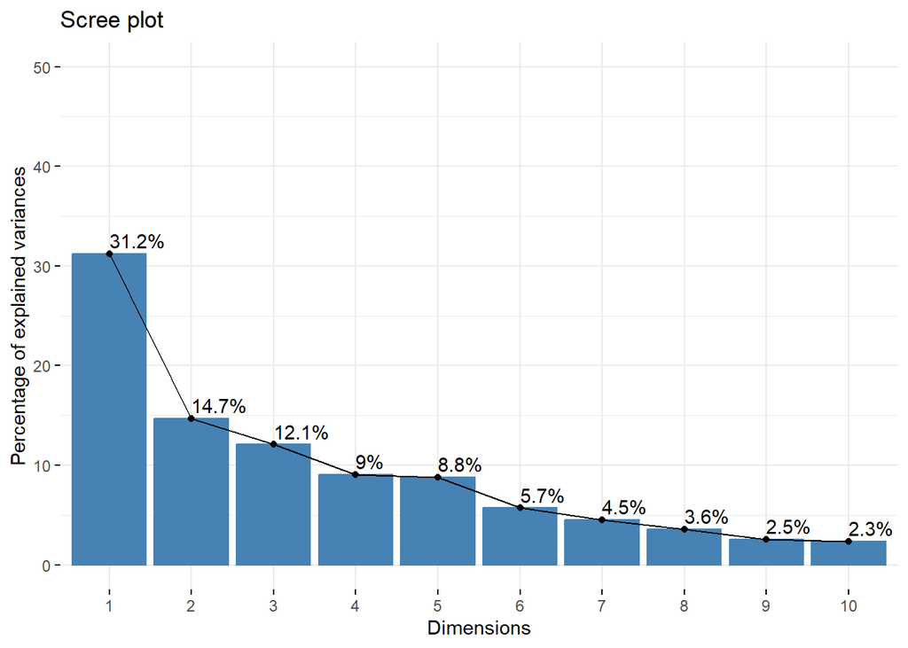

```r
# Create the scree plot
fviz_eig(pca_soil_data,
         addlabels = TRUE,
         ylim = c(0, 50))  # Adjust the y-axis limit if needed
```

X-axis (Dimensions): Represents the principal components, ordered by how much variance they explain in % (PC1, PC2, …, PC10).

Y-axis (Percentage of Explained Variance): Shows the proportion of the total variance explained by each principle component.

Bars: The height of each bar indicates the percentage of variance explained by that component.

Line with Dots: Helps visualize the trend in explained variance across components.

Applying the Elbow rule we have selected the first two componets pc1 and pc2 to expalian the variations in the soil properties.

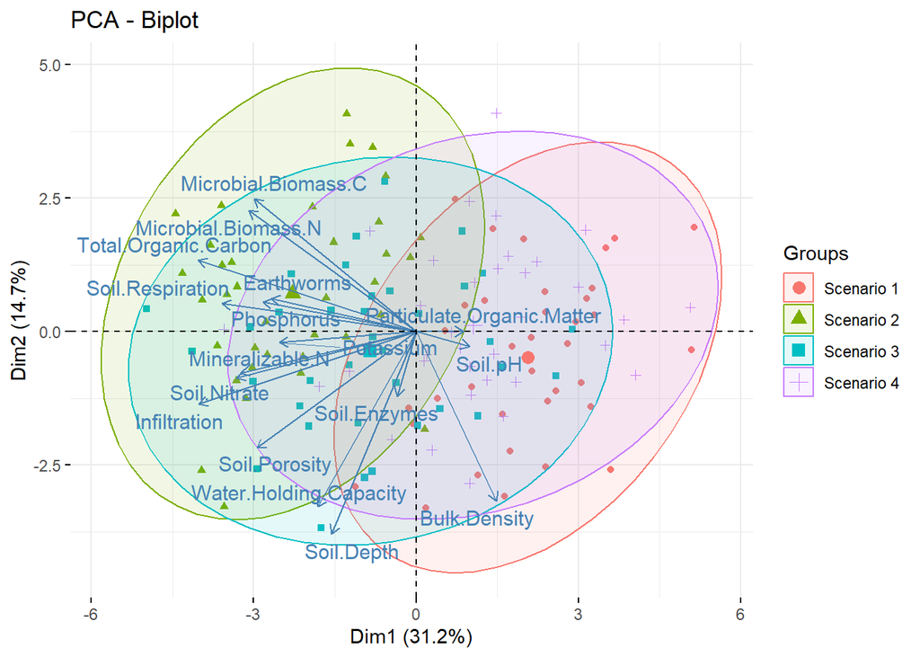

```r
# PCA biplot colored by climate
fviz_pca_biplot(pca_soil_data,
                label = "var", # Show variable names
                habillage = soil_data$climate, # Color by climate
                addEllipses = TRUE, # Add confidence ellipses
                ellipse.level = 0.95, # 95% confidence ellipses
                repel = TRUE) # Avoid text overlapping
```

Biplot Relationship of Soil Properties in PC1 and PC2 This biplot illustrates the relationship between soil properties and their distribution across different climate scenarios. Each point represents a sample, color-coded and shaped by scenario:

Key Insights 1. Ellipses: Confidence regions indicating where most points in each scenario lie, showing the distribution of principal components (PCs) within each scenario. 2. Arrows: Representing soil properties, with length quantifying their contribution. Arrows in the same direction indicate correlated properties.

Soil Property Grouping

Interpreting Relationships Scenario positions relative to arrows reveal:

- Scenario 1: Aligns with Soil pH and Bulk Density.
- Scenario 2: Associated with Microbial Biomass, Organic Carbon, and Earthworms.
- Scenario 3: Closer to Water Holding Capacity and Soil Depth.
- Scenario 4: Somewhat central, leaning toward Soil Enzymes and Soil pH.

CO₂ removal (Scenario 2) has the strongest positive biological impact on soils.

Sustainable energy (Scenario 3) yields balanced soil benefits.

Transportation interventions (Scenario 4) may have weaker or indirect effects on soil.

No intervention (Scenario 1) risks degraded soil quality, especially structurally.

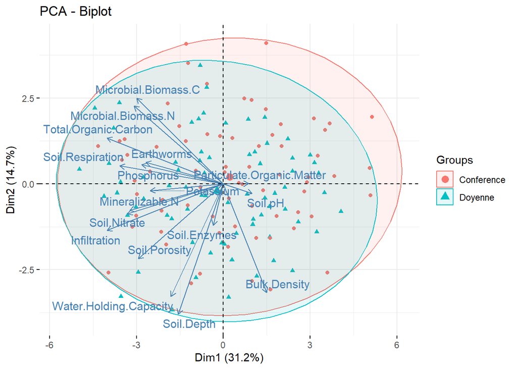

```r
# PCA biplot colored by species
fviz_pca_biplot(pca_soil_data,
                label = "var", # Show variable names (soil variables)
                habillage = soil_data$species, # Color by species
                addEllipses = TRUE, # Add group ellipses
                ellipse.level = 0.95, # 95% confidence level
                repel = TRUE) # Avoid overlapping text
```

biplot shows very small differnces in the inforation of the soil or influence of soil by species

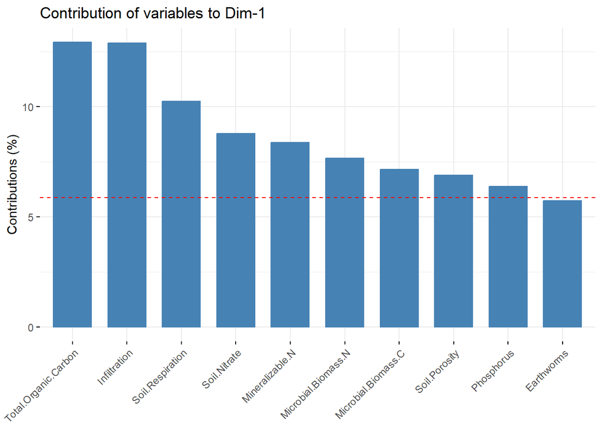

```r
#show contributions of variables to PC1
# Contribution of variables to PC1
fviz_contrib(pca_soil_data, choice = "var", axes = 1, top = 10)
```

pc1 contribution is mainly biological components of the data organinc matter

This bar plot shows the contributions (%) of individual variables to the first principal component (Dim-1) The y-axis indicates how much each variable contributes to the variance explained by PC1 (Dim-1).

Biological: Total Organic Carbon, Soil Respiration, Microbial Biomass.

Structural/Physical: Infiltration, Soil Porosity.

Nutrient-related: Soil Nitrate, Mineralizable N, Phosphorus.

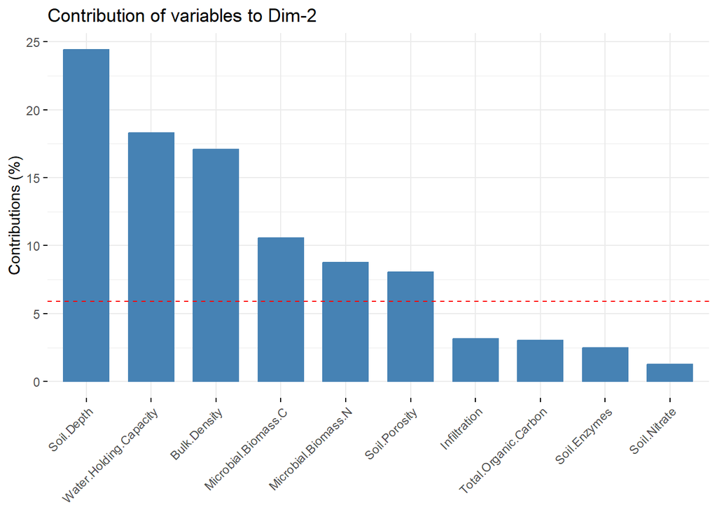

```r
# Contribution of variables to PC2
fviz_contrib(pca_soil_data, choice = "var", axes = 2, top = 10)
```

Dim-2 is largely driven by soil structural features:

Soil Depth, Water Holding Capacity, Bulk Density, and Porosity make up a large portion of the explained variance.

These variables reflect how well-structured and physically developed the soil is.

Biological activity is moderately represented:

Microbial Biomass C and N contribute meaningfully, suggesting some biological processes co-vary with structure.

Variables like Infiltration, Organic Carbon, and Enzymes contribute less, indicating PC2 is not dominated by biochemical or fertility traits.

Soil Nitrate is a minimal contributor to Dim-2 — its influence is mostly captured in Dim-1 (as we saw earlier).

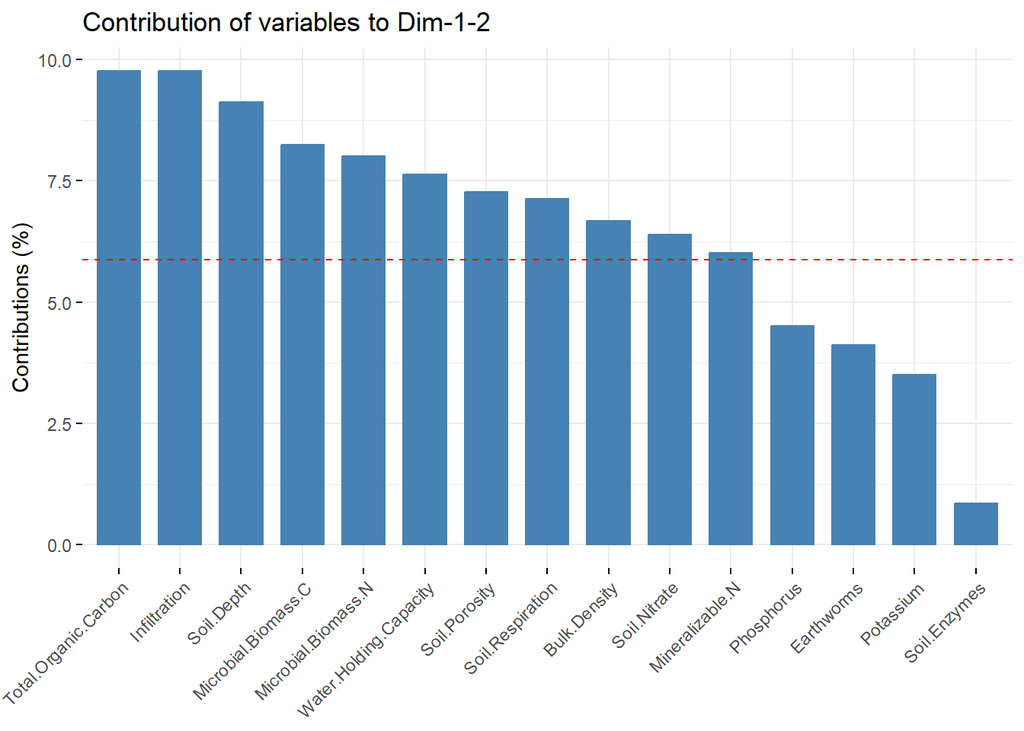

```r
# Combined plot for contributions to PC1 and PC2
fviz_contrib(pca_soil_data, choice = "var", axes = 1:2, top = 15)
```

PC1 (Dim-1): Dominated by organic fertility and microbial activity, including Total Organic Carbon, Infiltration, Soil Respiration, and Microbial Biomass.

PC2 (Dim-2): Strongly influenced by soil structure, especially Soil Depth, Water Holding Capacity, and Bulk Density.

Variables like Microbial Biomass C/N and Soil Porosity contribute meaningfully to both components, acting as bridging traits between biology and structure.

3. Explore/Visualize the soil condition features with a multivariate method.